# Assignment 2

Daniel Tomaro

2023-10-19

Task 1

```r
# Load the required packages
library(readr)
library(dplyr)
library(lubridate)
# Read the dataset
library(readr)
Studentmarks <- read_csv("Studentmarks.csv")
View(Studentmarks)
# Calculate age and add new column called Age1
Studentmarks$Age1 <- as.numeric(format(Sys.Date(), "%Y")) - as.numeric(format(as.Date(Studentmarks$dob, "%d/%m/%Y"), "%Y"))
# Print the updated dataset
print(Studentmarks)
```

```
## # A tibble: 10 × 7
##    StudentID Studentname dob        `2020` `2021` `2022`  Age1
##        <dbl> <chr>       <chr>       <dbl>  <dbl>  <dbl> <dbl>
##  1         1 Anna        12/12/1998     75     78     85    25
##  2         2 James       10/08/1999     65     74     52    24
##  3         3 Mary        21/08/1998     56     68     90    25
##  4         4 Antony      02/05/1999     78     65     85    24
##  5         5 Jacob       22/07/1998     85     78     65    25
##  6         6 Angelin     11/05/1998     65     68     70    25
##  7         7 Kellie      19/04/1999     78     52     88    24
##  8         8 Jesse       27/06/1998     77     72     75    25
##  9         9 John        15/10/1998     90     87     88    25
## 10        10 Therese     06/11/1998     95     85     75    25
```

```r
# Split DOB into Day, Month and Year
Studentmarks$Day <- format(as.Date(Studentmarks$dob, format = "%d/%m/%Y"), "%d")
Studentmarks$Month <- format(as.Date(Studentmarks$dob, format = "%d/%m/%Y"), "%m")
Studentmarks$Year <- format(as.Date(Studentmarks$dob, format = "%d/%m/%Y"), "%Y")
# Calculate the age based on the "Year" column
Studentmarks$Year <- as.numeric(Studentmarks$Year)
current_year <- as.numeric(format(Sys.Date(), "%Y"))
Studentmarks$Age2 <- current_year - Studentmarks$Year
# Print the updated dataset
print(Studentmarks)
```

```
## # A tibble: 10 × 11
##    StudentID Studentname dob        `2020` `2021` `2022`  Age1 Day   Month  Year
##        <dbl> <chr>       <chr>       <dbl>  <dbl>  <dbl> <dbl> <chr> <chr> <dbl>
##  1         1 Anna        12/12/1998     75     78     85    25 12    12     1998
##  2         2 James       10/08/1999     65     74     52    24 10    08     1999
##  3         3 Mary        21/08/1998     56     68     90    25 21    08     1998
##  4         4 Antony      02/05/1999     78     65     85    24 02    05     1999
##  5         5 Jacob       22/07/1998     85     78     65    25 22    07     1998
##  6         6 Angelin     11/05/1998     65     68     70    25 11    05     1998
##  7         7 Kellie      19/04/1999     78     52     88    24 19    04     1999
##  8         8 Jesse       27/06/1998     77     72     75    25 27    06     1998
##  9         9 John        15/10/1998     90     87     88    25 15    10     1998
## 10        10 Therese     06/11/1998     95     85     75    25 06    11     1998
## # ℹ 1 more variable: Age2 <dbl>
```

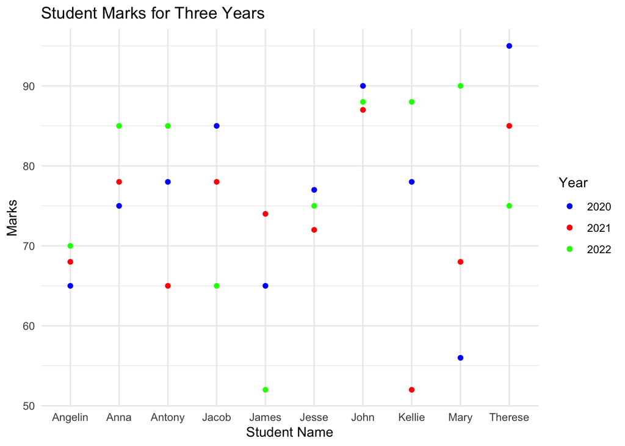

```r
# Load the ggplot2 library
library(ggplot2)
# Create a scatter plot
plot <- ggplot(Studentmarks, aes(x = Studentname)) +
  geom_point(aes(y = `2020`, color = "2020")) +
  geom_point(aes(y = `2021`, color = "2021")) +
  geom_point(aes(y = `2022`, color = "2022")) +
  labs(title = "Student Marks for Three Years", x = "Student Name", y = "Marks") +
  scale_color_manual(values = c("2020" = "blue", "2021" = "red", "2022" = "green")) +
  theme_minimal() +
  guides(color = guide_legend(title = "Year"))
# Show the plot
print(plot)
```

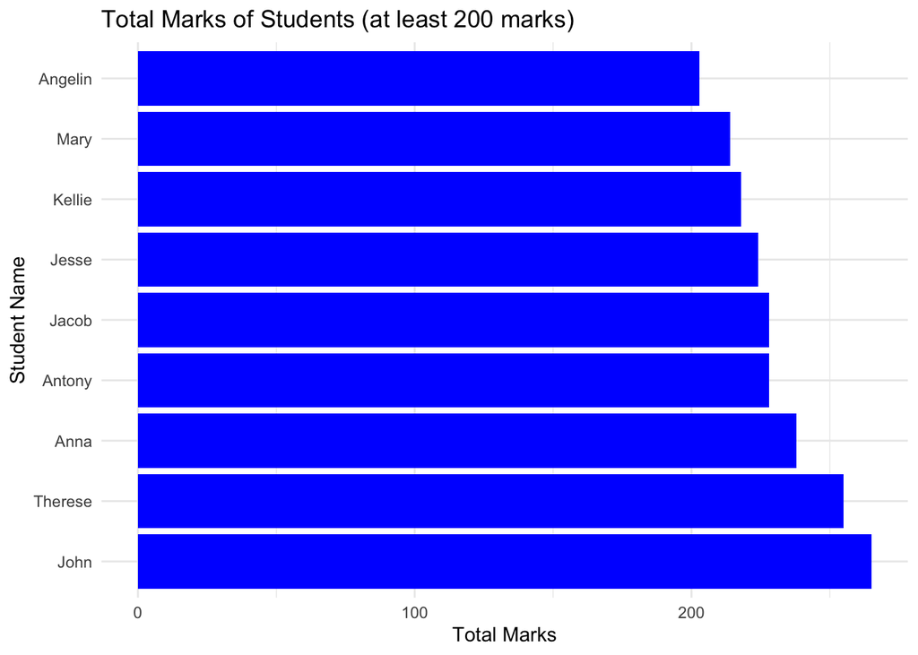

```r
# Calculate the total marks for each student
Studentmarks$totalmarks <- rowSums(Studentmarks[, c("2020", "2021", "2022")])
# Filter students who got at least 200 marks
filtered_data <- subset(Studentmarks, totalmarks >= 200)
# Sort the data by total marks in descending order
filtered_data <- filtered_data[order(-filtered_data$totalmarks),]
# Create a bar chart
library(ggplot2)
plot <- ggplot(filtered_data, aes(x = reorder(Studentname, -totalmarks), y = totalmarks)) +
  geom_bar(stat = "identity", fill = "blue") +
  labs(title = "Total Marks of Students (at least 200 marks)", x = "Student Name", y = "Total Marks") +
  theme_minimal() +
  coord_flip()
# Show the bar chart
print(plot)
```

Task 2

```r
# Read the data
library(readr)
Movies <- read_csv("Movies.csv")
View(Movies)
# Identify missing values
# Check for missing values in the entire "Movies" dataset
missing_values <- sum(is.na(Movies))
# Check for missing values in each column of the "Movies" dataset
missing_values_by_column <- colSums(is.na(Movies))
# Print the total number of missing values in the "Movies" dataset
cat("Total missing values in the 'Movies' dataset: ", missing_values, "\n")
```

```
## Total missing values in the 'Movies' dataset:  226
```

```r
# Print missing values count for each column
for (col_name in names(missing_values_by_column)) {
  cat("Column '", col_name, "': ", missing_values_by_column[col_name], " missing values\n")
}
```

```
## Column ' Color ':  2  missing values
## Column ' Director ':  0  missing values
## Column ' Reviews ':  1  missing values
## Column ' Duration ':  1  missing values
## Column ' Director_facebook_likes ':  0  missing values
## Column ' Actor_3_facebook_likes ':  10  missing values
## Column ' Actor_2_name ':  5  missing values
## Column ' Actor_1_facebook_likes ':  3  missing values
## Column ' Gross ':  0  missing values
## Column ' Genre ':  0  missing values
## Column ' Actor_1_name ':  3  missing values
## Column ' Title ':  0  missing values
## Column ' Votes ':  0  missing values
## Column ' Cast_total_facebook_likes ':  0  missing values
## Column ' Actor_3_name ':  10  missing values
## Column ' Facenumber_in_poster ':  6  missing values
## Column ' Plot_keywords ':  31  missing values
## Column ' Movie_imdb_link ':  0  missing values
## Column ' Language ':  0  missing values
## Column ' Content_rating ':  74  missing values
## Column ' Budget ':  0  missing values
## Column ' Year ':  0  missing values
## Column ' Actor_2_facebook_likes ':  5  missing values
## Column ' Imdb_score ':  0  missing values
## Column ' Aspect_ratio ':  75  missing values
## Column ' Movie_facebook_likes ':  0  missing values
```

```r
# Handle missing values
# Impute the average for the "Reviews" column
average_reviews <- mean(Movies$Reviews, na.rm = TRUE)
Movies$Reviews[is.na(Movies$Reviews)] <- average_reviews
# Impute the average for the "Duration" column
average_duration <- mean(Movies$Duration, na.rm = TRUE)
Movies$Duration[is.na(Movies$Duration)] <- average_duration
# Impute the average for the "Actor_3_facebook_likes" column
average_actor3_likes <- mean(Movies$Actor_3_facebook_likes, na.rm = TRUE)
Movies$Actor_3_facebook_likes[is.na(Movies$Actor_3_facebook_likes)] <- average_actor3_likes
# Impute the average for the "Actor_1_facebook_likes" column
average_actor1_likes <- mean(Movies$Actor_1_facebook_likes, na.rm = TRUE)
Movies$Actor_1_facebook_likes[is.na(Movies$Actor_1_facebook_likes)] <- average_actor1_likes
# Impute the average for the "Facenumber_in_poster" column
average_facenumber <- mean(Movies$Facenumber_in_poster, na.rm = TRUE)
Movies$Facenumber_in_poster[is.na(Movies$Facenumber_in_poster)] <- average_facenumber
# Delete the "Color" column
Movies <- Movies[, -which(names(Movies) == "Color")]
# Delete the "Actor_2_name" column
Movies <- Movies[, -which(names(Movies) == "Actor_2_name")]
# Delete the "Actor_1_name" column
Movies <- Movies[, -which(names(Movies) == "Actor_1_name")]
# Delete the "Plot_keywords" column
Movies <- Movies[, -which(names(Movies) == "Plot_keywords")]
# Delete the "Content_rating" column
Movies <- Movies[, -which(names(Movies) == "Content_rating")]
# Delete the "Aspect_ratio" column
Movies <- Movies[, -which(names(Movies) == "Aspect_ratio")]
# Print updated data
View(Movies)
```

Reasons for handling missing values the way they were handled:

Delete the “Color” column: Reason: The “Color” column appears to have only two unique values and doesn’t provide significant information. It’s not relevant to the analysis.

Impute the average for the “Reviews” column: Reason: The “Reviews” columnn is not the actual rating of the movie it corresponds to but rather just the amount of reviews it has recieved. Imputing the average should not affect the analysis that much as it doesnt actually provide us any information on said “Review”

Impute the average for the “Duration” column: Reason: “Duration” is numeric, and imputing the average is a reasonable approach, as it’s unlikely to have a direct correlation with the rating or profit but still necessary due to it being numeric.

Impute the average for the “Actor_3_facebook_likes” column: Reason: Similar to “Duration,” imputing the average for missing values in “Actor_3_facebook_likes” is appropriate.

Delete the “Actor_2_name” column: Reason: The name of the second actor is not relevant for the analysis, and it’s formatted as characters.

Impute the average for the “Actor_1_facebook_likes” column: Reason: Just like “Actor_3_facebook_likes,” imputing the average for missing values in “Actor_1_facebook_likes” is suitable.

Delete the “Actor_1_name” column: Reason: Similar to “Actor_2_name,” the name of the first actor is not relevant for the analysis, and it’s formatted as characters.

Impute the average for the “Facenumber_in_poster” column: Reason: “Facenumber_in_poster” is numeric and can be imputed with the average as it’s unlikely to have a direct correlation with rating or profit although is necessary due to being numeric

Delete the “Plot_keywords” column: Reason: “Plot_keywords” may not be necessary for the analysis, and it’s covered by the “Genre” column.

Delete the “Content_rating” column: Reason: There are too many missing values in the “Content_rating” column.

Delete the “Aspect_ratio” column: Reason: There are too many missing values in the “Aspect_ratio” column.

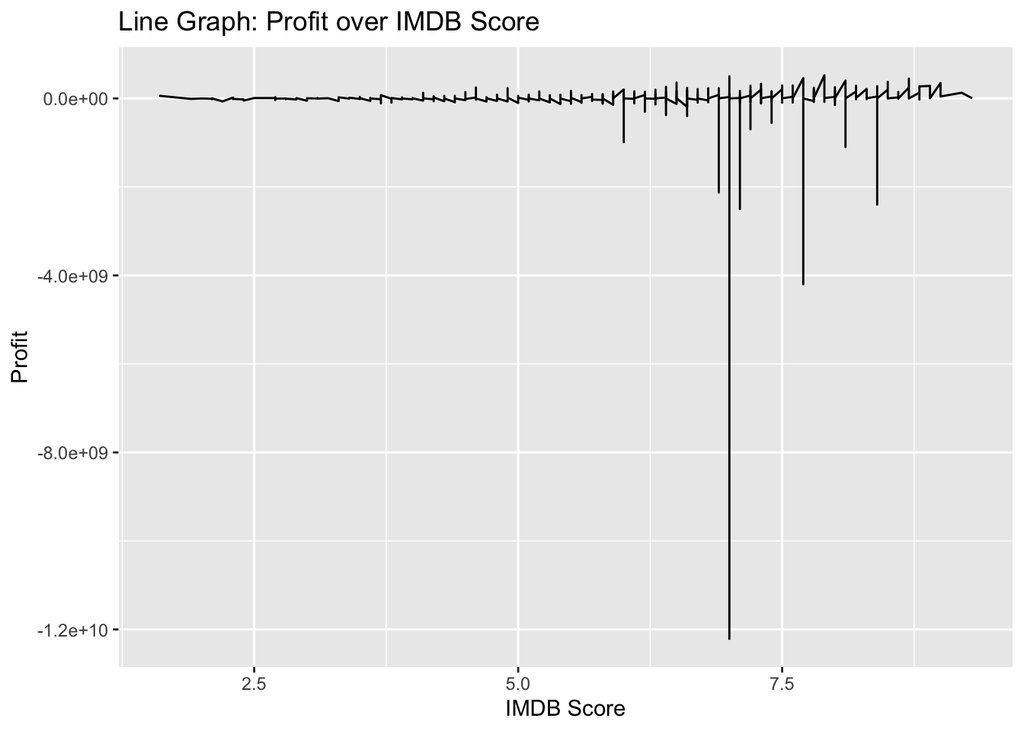

```r
library(ggplot2)
# Calculate profit for each movie and make it a new column
Movies$Profit <- Movies$Gross - Movies$Budget
# Create line graphs
# Line graph for Profit over IMDB Score
ggplot(Movies, aes(x = Imdb_score, y = Profit)) +
  geom_line() +
  labs(x = "IMDB Score", y = "Profit") +
  ggtitle("Line Graph: Profit over IMDB Score")
```

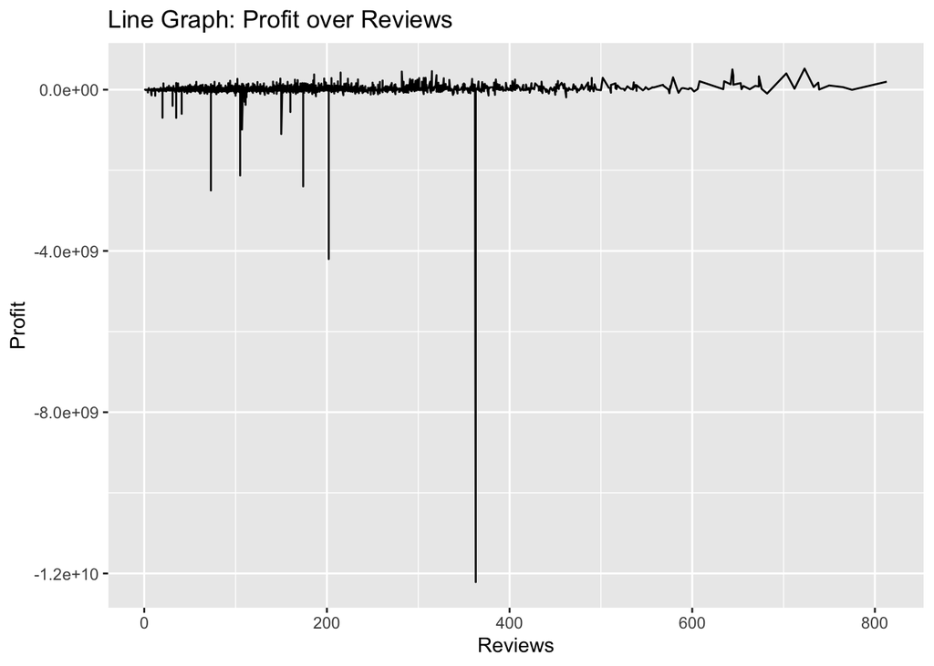

```r
# Line graph for Profit over Reviews
ggplot(Movies, aes(x = Reviews, y = Profit)) +
  geom_line() +
  labs(x = "Reviews", y = "Profit") +
  ggtitle("Line Graph: Profit over Reviews")
```

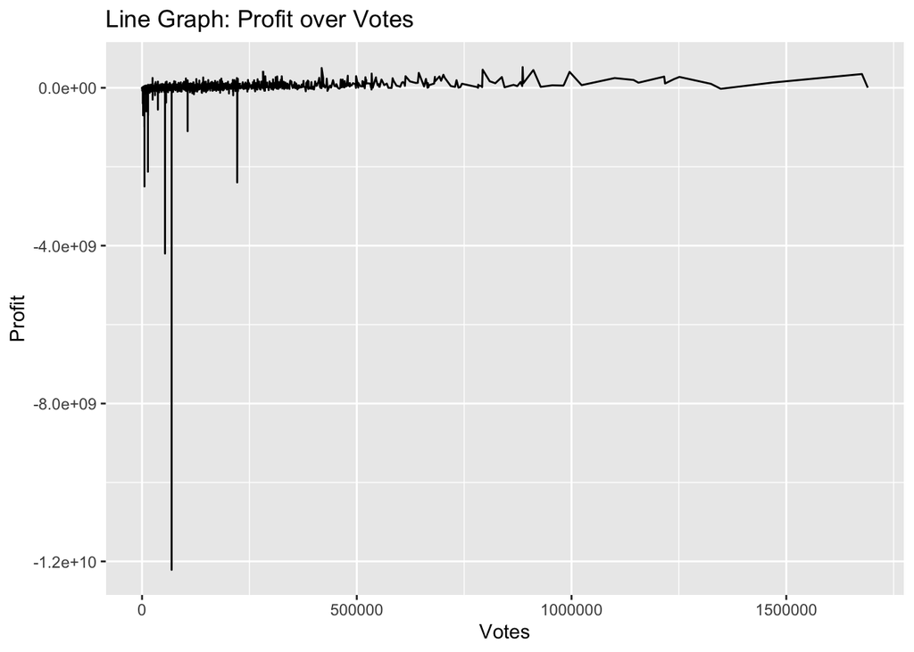

```r
# Line graph for Profit over Votes
ggplot(Movies, aes(x = Votes, y = Profit)) +
  geom_line() +
  labs(x = "Votes", y = "Profit") +
  ggtitle("Line Graph: Profit over Votes")
```

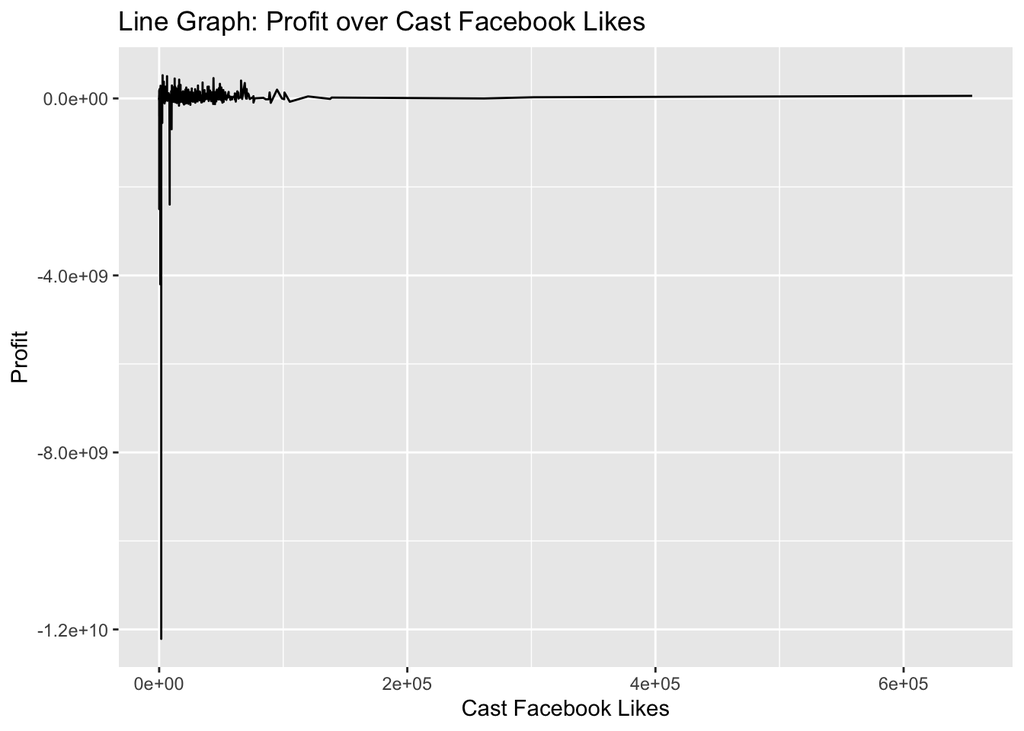

```r
# Line graph for Profit over Cast Facebook Likes
ggplot(Movies, aes(x = Cast_total_facebook_likes, y = Profit)) +
  geom_line() +
  labs(x = "Cast Facebook Likes", y = "Profit") +
  ggtitle("Line Graph: Profit over Cast Facebook Likes")
```

```r
# Calculate correlation coefficients
cor_profit_imdb <- cor(Movies$Profit, Movies$Imdb_score, method = "pearson")
cor_profit_reviews <- cor(Movies$Profit, Movies$Reviews, method = "pearson")
cor_profit_votes <- cor(Movies$Profit, Movies$Votes, method = "pearson")
cor_profit_facebook_likes <- cor(Movies$Profit, Movies$Cast_total_facebook_likes, method = "pearson")
# Print correlation coefficients
cat("Correlation between Profit and IMDB Score:", cor_profit_imdb, "\n")
```

```
## Correlation between Profit and IMDB Score: 0.03663351
```

```r
cat("Correlation between Profit and Reviews:", cor_profit_reviews, "\n")
```

```
## Correlation between Profit and Reviews: 0.04134491
```

```r
cat("Correlation between Profit and Votes:", cor_profit_votes, "\n")
```

```
## Correlation between Profit and Votes: 0.1271809
```

```r
cat("Correlation between Profit and Cast Facebook Likes:", cor_profit_facebook_likes, "\n")
```

```
## Correlation between Profit and Cast Facebook Likes: 0.04256315
```

Summary of Findings

Firstly, we used pearson correlation because: Pearson correlation quantifies the strength and direction of the linear relationship between two variables. It helps you determine if there is a positive (direct) or negative (inverse) linear association between the variables. Pearson correlation is scale-independent. This means that it doesn’t matter what units of measurement you’re using for your variables; the correlation coefficient remains the same. This makes it easier to compare relationships between different variables. Standardization: Pearson correlation involves standardization of variables, making it less sensitive to outliers than some other correlation methods. Outliers can have a significant impact on correlation measures like the Spearman rank correlation, but they have less influence on the Pearson correlation.

Correlation between Profit and IMDB Score (0.0366): There is a weak positive correlation (0.0366) between the profit of movies and their IMDB scores. This suggests that there is only a slight association between a movie’s financial success (profit) and its IMDB rating.

Correlation between Profit and Reviews (0.0413): Similarly, there is a weak positive correlation (0.0413) between the profit of movies and the number of reviews. This implies that there is a slight relationship between the profit of a movie and the quantity of reviews it receives.

Correlation between Profit and Votes (0.1272): There is a somewhat stronger positive correlation (0.1272) between profit and the number of votes a movie receives. This suggests that there is a more noticeable association between profit and the level of audience engagement and voting.

Correlation between Profit and Cast Facebook Likes (0.0426): There is a weak positive correlation (0.0426) between the profit of movies and the total Facebook likes of the movie’s cast. This indicates that there is a slight connection between a movie’s financial success and the popularity of its cast on social media.

In summary, the correlations between profit and these variables are generally weak, with the strongest correlation observed between profit and the number of votes. These findings suggest that profit may not be strongly influenced by individual movie characteristics,other factors and variables not included in this analysis may have a more significant impact on a movie’s financial success or they were too affected by the outliers in the data.

```r
# Calculate the correlation coefficients for all numeric variables
correlation_matrix <- cor(Movies[sapply(Movies, is.numeric)])
# Print the correlation matrix
print(correlation_matrix)
```

```
##                               Reviews     Duration Director_facebook_likes
## Reviews                    1.00000000  0.239228439              0.17925046
## Duration                   0.23922844  1.000000000              0.18079591
## Director_facebook_likes    0.17925046  0.180795910              1.00000000
## Actor_3_facebook_likes     0.25654240  0.127375054              0.11940454
## Actor_1_facebook_likes     0.17211391  0.087158435              0.09158766
## Gross                      0.47698968  0.252763672              0.14215751
## Votes                      0.60043695  0.344130219              0.30184681
## Cast_total_facebook_likes  0.25485596  0.143467224              0.27317743
## Facenumber_in_poster      -0.03373746  0.032254594             -0.04719989
## Budget                     0.10766561  0.069573886              0.01923478
## Year                       0.39241474 -0.128197037             -0.04578147
## Actor_2_facebook_likes             NA           NA                      NA
## Imdb_score                 0.34018987  0.358176420              0.18929261
## Movie_facebook_likes       0.70339692  0.221712551              0.16255474
## Profit                     0.04134491  0.009598722              0.02495955
##                           Actor_3_facebook_likes Actor_1_facebook_likes
## Reviews                               0.25654240             0.17211391
## Duration                              0.12737505             0.08715843
## Director_facebook_likes               0.11940454             0.09158766
## Actor_3_facebook_likes                1.00000000             0.25383394
## Actor_1_facebook_likes                0.25383394             1.00000000
## Gross                                 0.30290522             0.14884951
## Votes                                 0.27106196             0.18356680
## Cast_total_facebook_likes             0.45401489             0.94228746
## Facenumber_in_poster                  0.10423134             0.06460252
## Budget                                0.04121625             0.01754345
## Year                                  0.11147194             0.09128214
## Actor_2_facebook_likes                        NA                     NA
## Imdb_score                            0.06493351             0.09193077
## Movie_facebook_likes                  0.27189010             0.13158404
## Profit                                0.05295565             0.02868779
##                                 Gross       Votes Cast_total_facebook_likes
## Reviews                    0.47698968  0.60043695                0.25485596
## Duration                   0.25276367  0.34413022                0.14346722
## Director_facebook_likes    0.14215751  0.30184681                0.27317743
## Actor_3_facebook_likes     0.30290522  0.27106196                0.45401489
## Actor_1_facebook_likes     0.14884951  0.18356680                0.94228746
## Gross                      1.00000000  0.63140421                0.23399137
## Votes                      0.63140421  1.00000000                0.28256961
```

[output cut: 41 more lines]

```
## Reviews                             0.70339692  0.041344910
## Duration                            0.22171255  0.009598722
## Director_facebook_likes             0.16255474  0.024959550
## Actor_3_facebook_likes              0.27189010  0.052955650
## Actor_1_facebook_likes              0.13158404  0.028687791
## Gross                               0.37545543  0.208148261
## Votes                               0.52264949  0.127180855
## Cast_total_facebook_likes           0.21443396  0.042563146
## Facenumber_in_poster                0.01567864  0.012165565
## Budget                              0.05469570 -0.951709432
## Year                                0.29554083 -0.029862285
## Actor_2_facebook_likes                      NA           NA
## Imdb_score                          0.27734918  0.036633513
## Movie_facebook_likes                1.00000000  0.062092193
## Profit                              0.06209219  1.000000000
```

Summary of Findings

Findings:

Reviews have a weak positive correlation with Profit (0.0413).

Duration has a very weak positive correlation with Profit (0.0096).

Director Facebook Likes have a very weak positive correlation with Profit (0.0250).

Actor_3 Facebook Likes have a very weak positive correlation with Profit (0.0529).

Actor_1 Facebook Likes have a very weak positive correlation with Profit (0.0287).

Gross has a moderate positive correlation with Profit (0.2081).

Votes have a weak positive correlation with Profit (0.1272).

Cast Total Facebook Likes have a very weak positive correlation with Profit (0.0426).

Face Number in Poster has a very weak positive correlation with Profit (0.0122).

Budget has a strong negative correlation with Profit (-0.9517).

Year has a very weak negative correlation with Profit (-0.0299).

Movie Facebook Likes have a weak positive correlation with Profit (0.0621).

It’s important to note that the correlations are relatively weak, indicating that Profit may not be strongly dependent on individual movie characteristics. However, Gross, Votes, and Budget seem to have some influence on Profit, with Gross showing the strongest positive correlation.

Strong Correlations:

Votes and Gross (0.6314): There is a strong positive correlation (0.6314) between the number of votes a movie receives and its gross earnings. This suggests that movies with higher gross earnings tend to attract more votes. The reason for this strong correlation could be that popular and successful movies often receive more attention and engagement from the audience, resulting in a higher number of votes.

Votes and Movie Facebook Likes (0.5226): There is a strong positive correlation (0.5226) between the number of votes a movie receives and the number of Facebook likes for the movie. This indicates that movies with more Facebook likes also tend to receive more votes. The reasoning behind this could be that movies with a strong online presence and a dedicated fan base are likely to attract more votes from their followers.

Weak Correlations:

Actor_1 Facebook Likes and Facenumber in Poster (0.0646): There is a weak positive correlation (0.0646) between the number of Facebook likes of the lead actor and the number of face numbers in the movie poster. This correlation is relatively weak, suggesting that there is not a strong relationship between the popularity of the lead actor and the complexity of the movie poster.

Actor_3 Facebook Likes and Director Facebook Likes (0.1194): There is a weak positive correlation (0.1194) between the Facebook likes of the third actor and the Facebook likes of the director. This suggests that there is only a slight connection between the popularity of the third actor and the director. The weak correlation could mean that the success of a movie is not heavily dependent on the combination of these two factors.

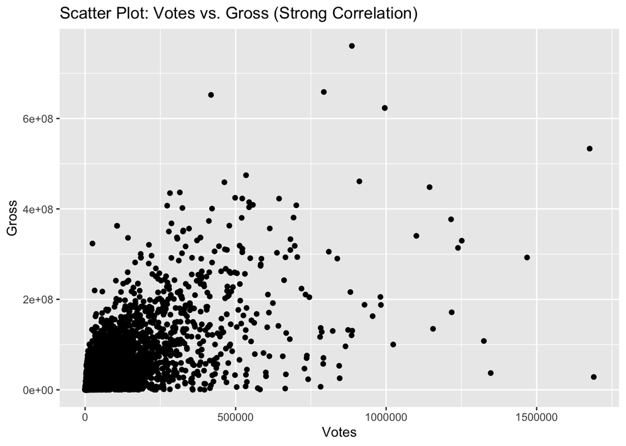

```r
# Scatter plot for Votes vs. Gross (Strong Correlation)
ggplot(Movies, aes(x = Votes, y = Gross)) +
  geom_point() +
  labs(x = "Votes", y = "Gross") +
  ggtitle("Scatter Plot: Votes vs. Gross (Strong Correlation)")
```

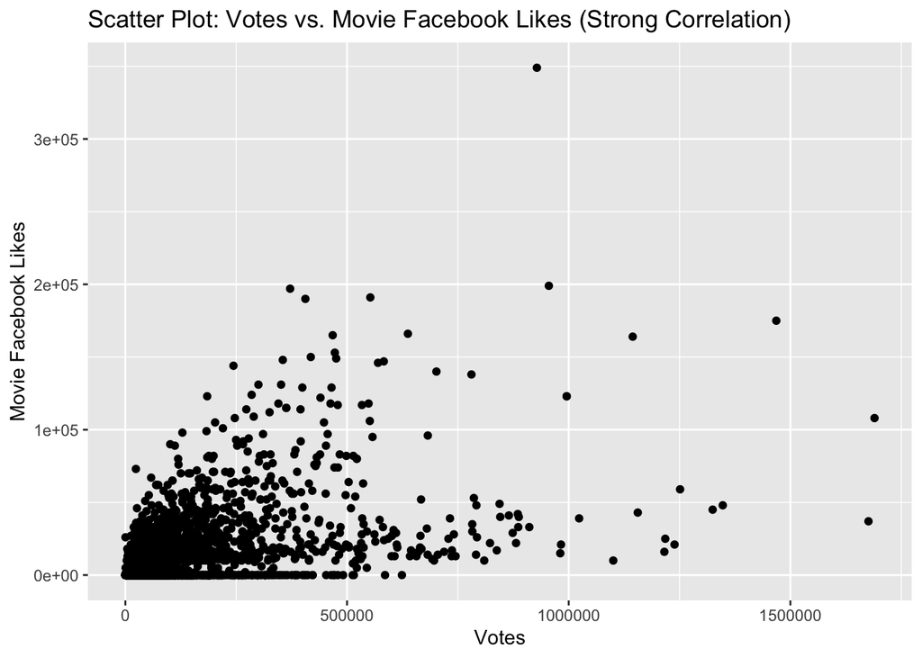

```r
# Scatter plot for Votes vs. Movie Facebook Likes (Strong Correlation)
ggplot(Movies, aes(x = Votes, y = Movie_facebook_likes)) +
  geom_point() +
  labs(x = "Votes", y = "Movie Facebook Likes") +
  ggtitle("Scatter Plot: Votes vs. Movie Facebook Likes (Strong Correlation)")
```

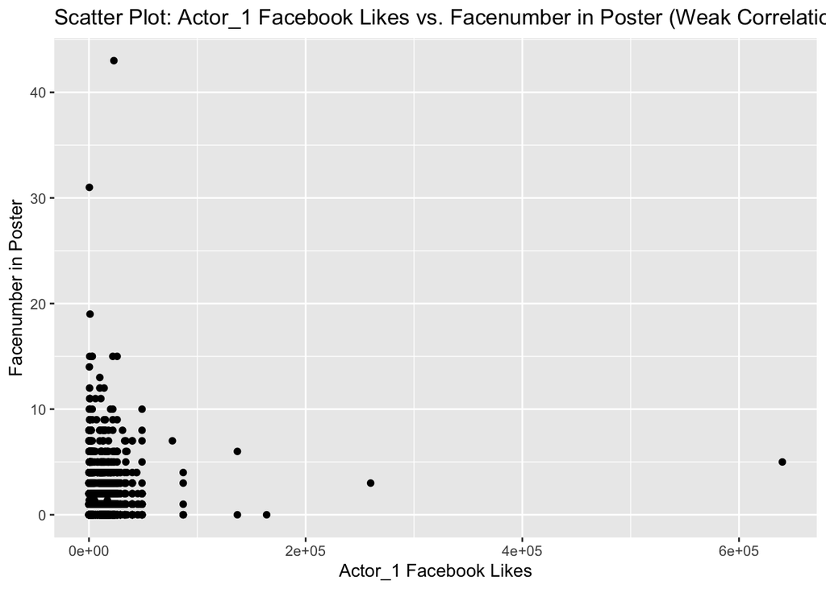

```r
# Scatter plot for Actor_1 Facebook Likes vs. Facenumber in Poster (Weak Correlation)
ggplot(Movies, aes(x = Actor_1_facebook_likes, y = Facenumber_in_poster)) +
  geom_point() +
  labs(x = "Actor_1 Facebook Likes", y = "Facenumber in Poster") +
  ggtitle("Scatter Plot: Actor_1 Facebook Likes vs. Facenumber in Poster (Weak Correlation)")
```

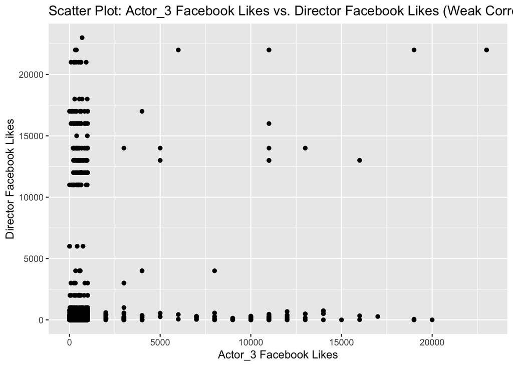

```r
# Scatter plot for Actor_3 Facebook Likes vs. Director Facebook Likes (Weak Correlation)
ggplot(Movies, aes(x = Actor_3_facebook_likes, y = Director_facebook_likes)) +
  geom_point() +
  labs(x = "Actor_3 Facebook Likes", y = "Director Facebook Likes") +
  ggtitle("Scatter Plot: Actor_3 Facebook Likes vs. Director Facebook Likes (Weak Correlation)")
```

Task 3

```r
library(readr)
library(readr)
MobilePhoneData <- read_csv("MobilePhoneData.csv",
    col_names = FALSE)
View(MobilePhoneData)
MobilePhoneData <- MobilePhoneData %>%
  select(-X1)
View(MobilePhoneData)
# Identify missing values
missing_values <- sum(is.na(MobilePhoneData))
# Check for missing values in each column of the "MobilePhoneData" dataset
missing_values_by_column <- colSums(is.na(MobilePhoneData))
# Print the total number of missing values in the "MobilePhoneData" dataset
cat("Total missing values in the 'MobilePhoneData' dataset: ", missing_values, "\n")
```

```
## Total missing values in the 'MobilePhoneData' dataset:  439
```

```r
# Print missing values count for each column
for (col_name in names(missing_values_by_column)) {
  cat("Column '", col_name, "': ", missing_values_by_column[col_name], " missing values\n")
}
```

```
## Column ' X2 ':  1  missing values
## Column ' X3 ':  0  missing values
## Column ' X4 ':  1  missing values
## Column ' X5 ':  2  missing values
## Column ' X6 ':  1  missing values
## Column ' X7 ':  2  missing values
## Column ' X8 ':  1  missing values
## Column ' X9 ':  1  missing values
## Column ' X10 ':  1  missing values
## Column ' X11 ':  3  missing values
## Column ' X12 ':  2  missing values
## Column ' X13 ':  2  missing values
## Column ' X14 ':  1  missing values
## Column ' X15 ':  1  missing values
## Column ' X16 ':  2  missing values
## Column ' X17 ':  1  missing values
## Column ' X18 ':  2  missing values
## Column ' X19 ':  1  missing values
## Column ' X20 ':  1  missing values
## Column ' X21 ':  3  missing values
## Column ' X22 ':  2  missing values
## Column ' X23 ':  1  missing values
## Column ' X24 ':  2  missing values
## Column ' X25 ':  0  missing values
## Column ' X26 ':  1  missing values
## Column ' X27 ':  1  missing values
## Column ' X28 ':  2  missing values
## Column ' X29 ':  3  missing values
## Column ' X30 ':  1  missing values
## Column ' X31 ':  4  missing values
## Column ' X32 ':  2  missing values
## Column ' X33 ':  2  missing values
## Column ' X34 ':  1  missing values
## Column ' X35 ':  1  missing values
## Column ' X36 ':  2  missing values
## Column ' X37 ':  1  missing values
## Column ' X38 ':  2  missing values
## Column ' X39 ':  3  missing values
## Column ' X40 ':  1  missing values
## Column ' X41 ':  2  missing values
```

[output cut: 245 more lines]

```
## Column ' X287 ':  1  missing values
## Column ' X288 ':  1  missing values
## Column ' X289 ':  1  missing values
## Column ' X290 ':  0  missing values
## Column ' X291 ':  3  missing values
## Column ' X292 ':  2  missing values
## Column ' X293 ':  2  missing values
## Column ' X294 ':  1  missing values
## Column ' X295 ':  2  missing values
## Column ' X296 ':  1  missing values
## Column ' X297 ':  2  missing values
## Column ' X298 ':  2  missing values
## Column ' X299 ':  2  missing values
## Column ' X300 ':  1  missing values
## Column ' X301 ':  1  missing values
```

```r
# Create a list of columns to remove
columns_to_remove <- names(missing_values_by_column[missing_values_by_column > 0])
# Remove the columns with one or more missing values
MobilePhoneData <- MobilePhoneData[, !names(MobilePhoneData) %in% columns_to_remove]
# Replace "YES" with 1 and "NO" with 0 in all columns of 'MobilePhoneData'
MobilePhoneData[] <- lapply(MobilePhoneData, function(x) ifelse(x == "YES", 1, ifelse(x == "NO", 0, x)))
# Print the modified data frame
print(MobilePhoneData)
```

```
## # A tibble: 21 × 28
##    X3    X25   X44   X46   X54   X56   X57   X68   X89   X93   X103  X131  X135
##    <chr> <chr> <chr> <chr> <chr> <chr> <chr> <chr> <chr> <chr> <chr> <chr> <chr>
##  1 2     24    43    45    53    55    56    67    88    92    102   130   134
##  2 875   514   1910  723   1723  1846  1524  1561  1380  1640  1989  1356  1972
##  3 1     1     1     0     1     1     0     0     1     0     0     1     0
##  4 0.7   1.6   1.7   0.5   1.1   1     2.1   0.5   2.1   0.5   1.8   0.5   1.2
##  5 1     0     0     0     1     0     1     1     1     1     1     1     1
##  6 1     7     0     0     1     5     6     10    1     1     16    0     0
##  7 0     1     0     1     0     1     1     1     1     1     1     0     0
##  8 30    37    34    3     42    53    64    4     4     36    10    35    37
##  9 0.7   0.1   0.6   0.2   1     0.7   0.4   0.5   0.8   0.9   0.9   0.8   0.7
## 10 146   172   115   168   164   106   83    134   92    87    86    131   102
## # ℹ 11 more rows
## # ℹ 15 more variables: X148 <chr>, X153 <chr>, X166 <chr>, X195 <chr>,
## #   X201 <chr>, X207 <chr>, X212 <chr>, X229 <chr>, X230 <chr>, X235 <chr>,
## #   X236 <chr>, X245 <chr>, X252 <chr>, X267 <chr>, X290 <chr>
```

Reason for removing the data

The reason I removed the data is because its all vital information in order to compare the phones and then be able to rank them. Without complete data there would be bias towards which phone is better or worse. I also removed all characters so its easier to work with.

```r
# Function to normalize
normalize_row <- function(row) {
  # Convert the row to a numeric vector, replacing NAs with 0
  row_numeric <- as.numeric(row)
  row_numeric[is.na(row_numeric)] <- 0

  min_val <- min(row_numeric)
  max_val <- max(row_numeric)
  if (max_val != min_val) {
    normalized_row <- 1 * (row_numeric - min_val) / (max_val - min_val)
  } else {
    normalized_row <- rep(0, length(row_numeric))
  }
  return(normalized_row)
}
# Apply the normalization function to each row
normalized_data <- as.data.frame(t(apply(MobilePhoneData, 1, normalize_row)))
# Print the normalized data
print(normalized_data)
```

```
##            V1         V2        V3        V4         V5         V6         V7
## 1  0.00000000 0.07665505 0.1428571 0.1498258 0.17770035 0.18466899 0.18815331
## 2  0.24309764 0.00000000 0.9400673 0.1407407 0.81414141 0.89696970 0.68013468
## 3  1.00000000 1.00000000 1.0000000 0.0000000 1.00000000 1.00000000 0.00000000
## 4  0.08695652 0.47826087 0.5217391 0.0000000 0.26086957 0.21739130 0.69565217
## 5  1.00000000 0.00000000 0.0000000 0.0000000 1.00000000 0.00000000 1.00000000
## 6  0.06250000 0.43750000 0.0000000 0.0000000 0.06250000 0.31250000 0.37500000
## 7  0.00000000 1.00000000 0.0000000 1.0000000 0.00000000 1.00000000 1.00000000
## 8  0.44262295 0.55737705 0.5081967 0.0000000 0.63934426 0.81967213 1.00000000
## 9  0.66666667 0.00000000 0.5555556 0.1111111 1.00000000 0.66666667 0.33333333
## 10 0.54782609 0.77391304 0.2782609 0.7391304 0.70434783 0.20000000 0.00000000
## 11 1.00000000 0.00000000 0.1428571 0.4285714 1.00000000 1.00000000 0.57142857
## 12 0.42105263 0.47368421 0.0000000 0.1578947 0.73684211 0.36842105 0.84210526
## 13 0.26848019 0.55647546 0.5736251 0.5351863 0.11058545 0.10053223 0.19869899
## 14 0.24128503 0.83595352 0.5358852 0.8530417 0.88243336 0.91045796 0.06288448
```

[output cut: 73 more lines]

The reason for normalizing the data

Data normalisation or scaling is the process of bringing all the feature values into the same range. Data often comes from different sources and in different units. Normalization brings all your data to a common scale, making it easier to compare and analyze. With our data each variable was measure very differently with same ranging between 0-1 and others well over a thousand which would result in a skewed and ugly visualization which what would seem like many outliers. Normalization removes the units of measurement as well, making it easier to interpret and compare the data. By normalizing data, you can more easily spot patterns and trends in the data because you remove the variations introduced by different scales. This allows you to focus on the inherent relationships between variables. Normalized data is more interpretative. It becomes easier to understand the impact of a unit change in one variable on the outcome when all variables are on the same scale.

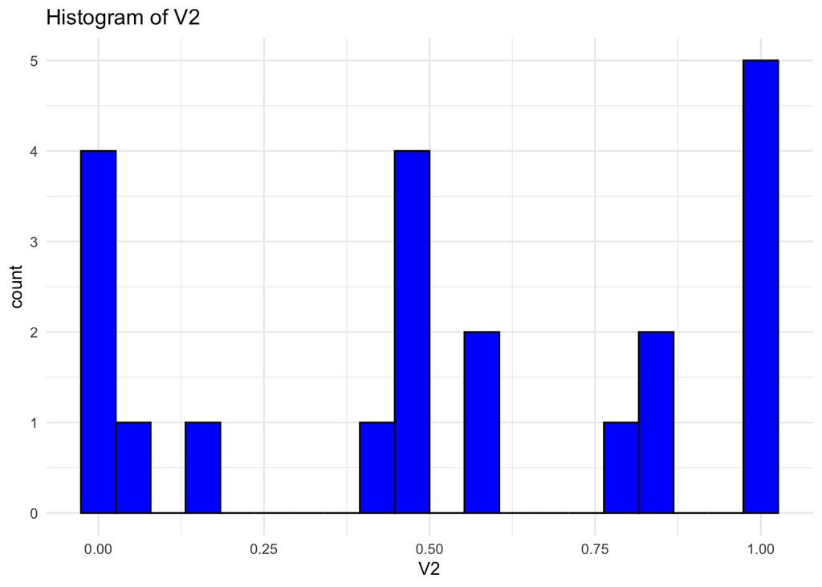

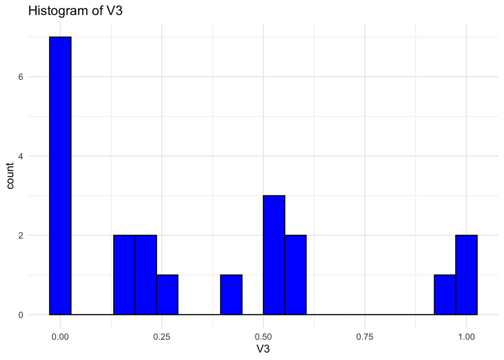

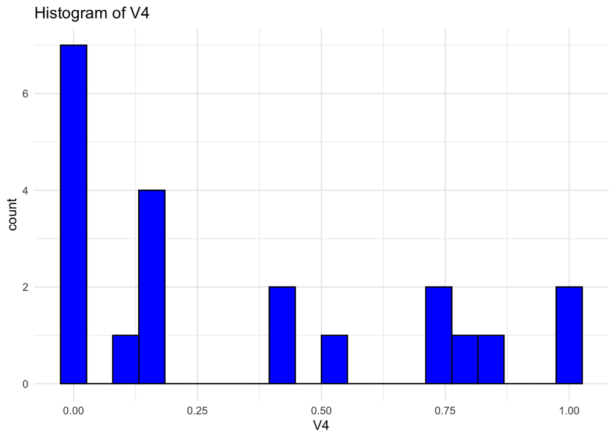

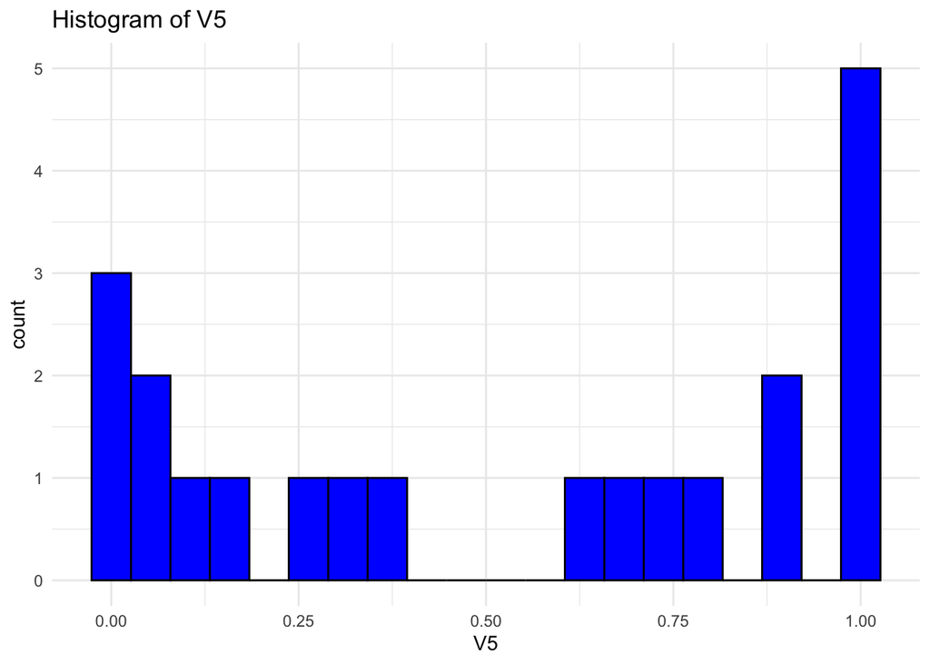

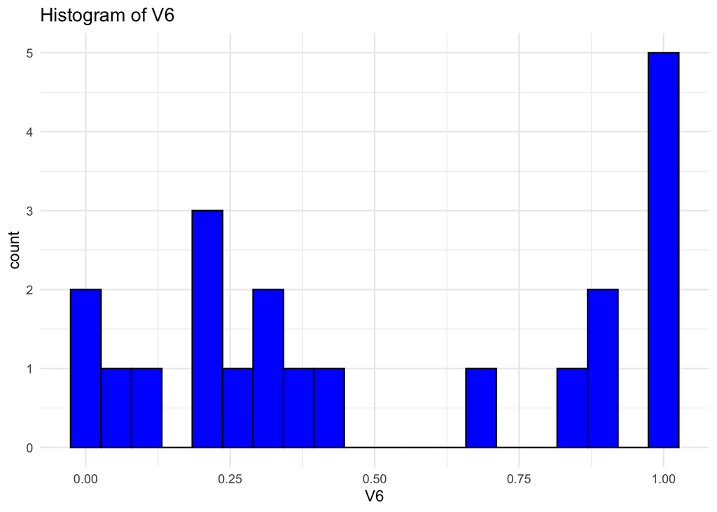

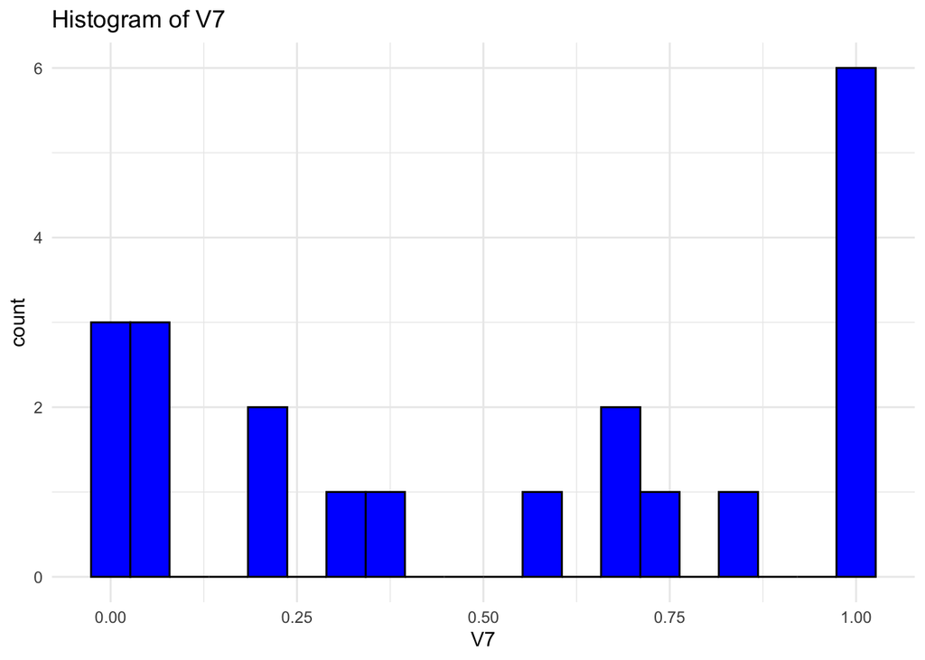

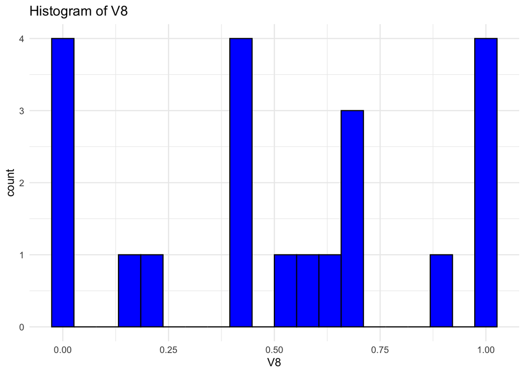

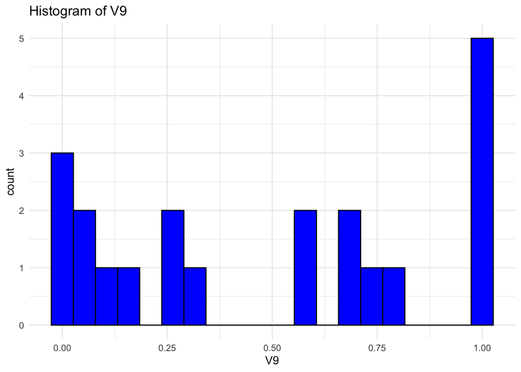

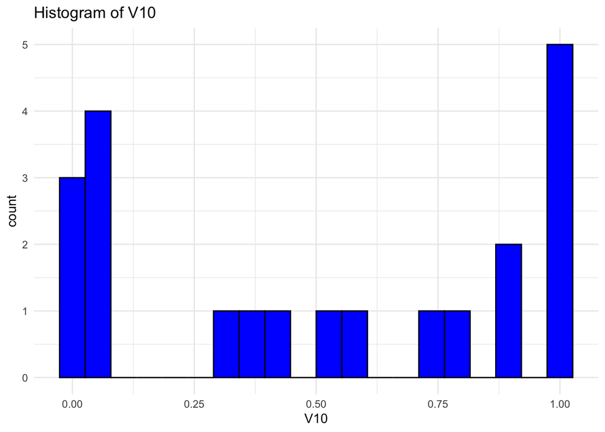

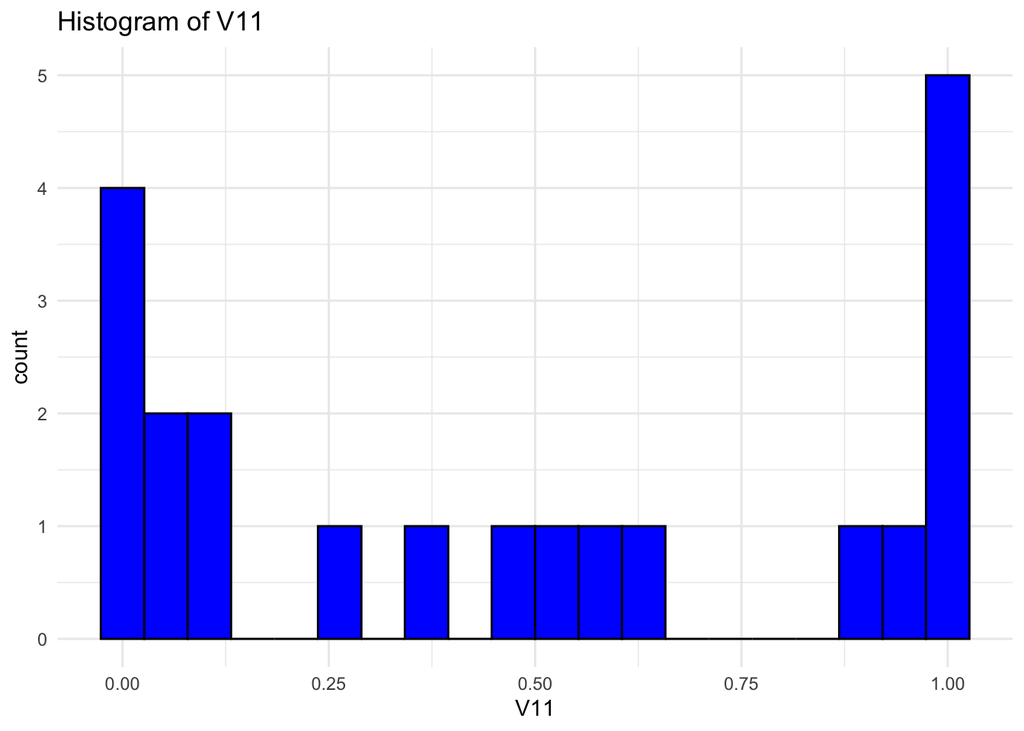

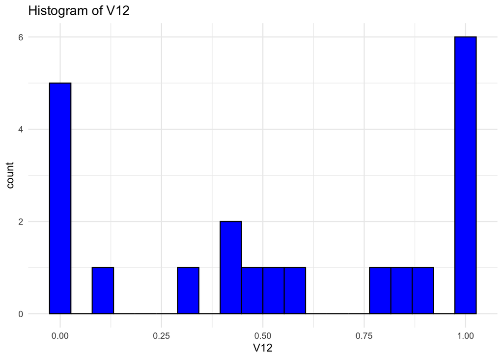

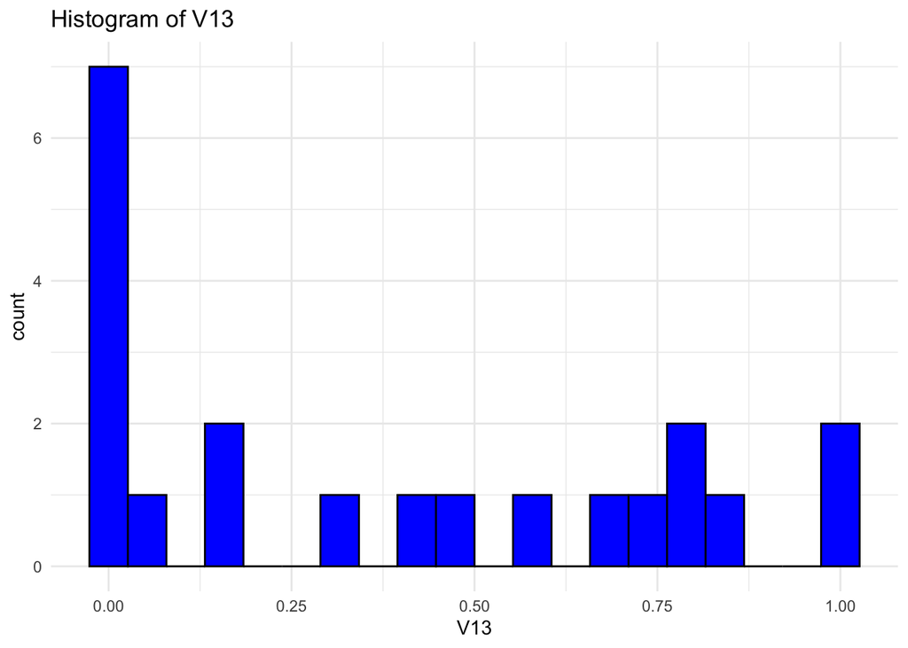

[15 more figures not shown]

```r
library(ggplot2)
# Create histograms for each variable and display them one by one (excluding 'ID')
for (col in names(normalized_data)[-1]) {  # Exclude the first column (ID)
  gg <- ggplot(normalized_data, aes_string(x = col)) +
    geom_histogram(fill = "blue", color = "black", bins = 20) +
    labs(title = paste("Histogram of", col)) +
    theme_minimal()

  print(gg)
}
```

```r
# Transpose the data frame
data_transposed <- t(MobilePhoneData)
# Create a new data frame with the first row as the header
new_header <- as.character(data_transposed[1, ])
new_data <- data.frame(data_transposed[-1, ], stringsAsFactors = FALSE)
# Set the new header
names(new_data) <- new_header
# Convert all values in the dataset to numeric
new_data <- as.data.frame(lapply(new_data, as.numeric))
str(new_data)
```

```
## 'data.frame':    27 obs. of  21 variables:
##  $ X2    : num  24 43 45 53 55 56 67 88 92 102 ...
##  $ X875  : num  514 1910 723 1723 1846 ...
##  $ X1    : num  1 1 0 1 1 0 0 1 0 0 ...
##  $ X0.7  : num  1.6 1.7 0.5 1.1 1 2.1 0.5 2.1 0.5 1.8 ...
##  $ X1.1  : num  0 0 0 1 0 1 1 1 1 1 ...
##  $ X1.2  : num  7 0 0 1 5 6 10 1 1 16 ...
##  $ X0    : num  1 0 1 0 1 1 1 1 1 1 ...
##  $ X30   : num  37 34 3 42 53 64 4 4 36 10 ...
##  $ X0.7.1: num  0.1 0.6 0.2 1 0.7 0.4 0.5 0.8 0.9 0.9 ...
##  $ X146  : num  172 115 168 164 106 83 134 92 87 86 ...
##  $ X8    : num  1 2 4 8 8 5 2 3 8 3 ...
##  $ X8.1  : num  9 0 3 14 7 16 13 13 11 18 ...
##  $ X469  : num  956 985 920 202 185 351 885 420 664 135 ...
##  $ X853  : num  1723 1284 1748 1791 1832 ...
##  $ X702  : num  3392 309 1851 3587 563 ...
##  $ X19   : num  12 8 15 10 9 6 13 13 6 14 ...
##  $ X15   : num  8 4 3 5 5 1 12 2 1 8 ...
##  $ X15.1 : num  5 10 16 3 10 2 10 15 10 4 ...
##  $ X1.3  : num  1 0 1 1 1 1 1 1 1 1 ...
##  $ X1.4  : num  1 0 0 0 0 1 1 1 0 0 ...
##  $ X1.5  : num  1 1 0 0 1 1 0 0 1 0 ...
```

```r
# Print the transposed data frame with the corrected header
print(new_data)
```

```
##     X2 X875 X1 X0.7 X1.1 X1.2 X0 X30 X0.7.1 X146 X8 X8.1 X469 X853 X702 X19 X15
## 1   24  514  1  1.6    0    7  1  37    0.1  172  1    9  956 1723 3392  12   8
## 2   43 1910  1  1.7    0    0  0  34    0.6  115  2    0  985 1284  309   8   4
## 3   45  723  0  0.5    0    0  1   3    0.2  168  4    3  920 1748 1851  15   3
## 4   53 1723  1  1.1    1    1  0  42    1.0  164  8   14  202 1791 3587  10   5
## 5   55 1846  1  1.0    0    5  1  53    0.7  106  8    7  185 1832  563   9   5
## 6   56 1524  0  2.1    1    6  1  64    0.4   83  5   16  351  592 2905   6   1
## 7   67 1561  0  0.5    1   10  1   4    0.5  134  2   13  885 1811 1783  13  12
## 8   88 1380  1  2.1    1    1  1   4    0.8   92  3   13  420  500  797  13   2
## 9   92 1640  0  0.5    1    1  1  36    0.9   87  8   11  664 1806 3235   6   1
## 10 102 1989  0  1.8    1   16  1  10    0.9   86  3   18  135  576 2158  14   8
## 11 130 1356  1  0.5    1    0  0  35    0.8  131  1   19  782  951 3451   5   2
## 12 134 1972  0  1.2    1    0  0  37    0.7  102  2    1  715 1648 2870  16   0
## 13 147 1883  1  2.6    0    2  1  50    0.1  169  5    3  313  561  427  17   8
## 14 152  793  1  1.9    1    0  1  43    0.3  124  8    2   15 1196 1050  11   9
```

[output cut: 41 more lines]

```r
# Calculate the mean of each column
mean_values <- colMeans(new_data, na.rm = TRUE)
cat("Mean Values:\n")
```

```
## Mean Values:
```

```r
print(mean_values)
```

```
##           X2         X875           X1         X0.7         X1.1         X1.2
##  153.3333333 1449.7037037    0.5185185    1.4555556    0.7037037    3.8148148
##           X0          X30       X0.7.1         X146           X8         X8.1
##    0.6666667   29.4074074    0.5407407  138.2222222    4.5925926   10.5185185
##         X469         X853         X702          X19          X15        X15.1
##  533.3703704 1242.6296296 2268.3703704   12.1851852    5.3703704    9.6296296
##         X1.3         X1.4         X1.5
##    0.8518519    0.4814815    0.5185185
```

```r
# Calculate the median of each column
median_values <- sapply(new_data, median, na.rm = TRUE)
cat("\nMedian Values:\n")
```

```
##
## Median Values:
```

```r
print(median_values)
```

```
##     X2   X875     X1   X0.7   X1.1   X1.2     X0    X30 X0.7.1   X146     X8
##  152.0 1524.0    1.0    1.6    1.0    2.0    1.0   33.0    0.6  139.0    5.0
##   X8.1   X469   X853   X702    X19    X15  X15.1   X1.3   X1.4   X1.5
##   11.0  420.0 1196.0 2158.0   13.0    4.0   10.0    1.0    0.0    1.0
```

```r
# Calculate the range (max - min) and min/max for each column
range_values <- sapply(new_data, function(x) {
  min_val <- min(x, na.rm = TRUE)
  max_val <- max(x, na.rm = TRUE)
  range_val <- max_val - min_val
  c(min = min_val, max = max_val, range = range_val)
})
cat("Range Values (Min, Max, and Range):\n")
```

```
## Range Values (Min, Max, and Range):
```

```r
print(range_values)
```

```
##        X2 X875 X1 X0.7 X1.1 X1.2 X0 X30 X0.7.1 X146 X8 X8.1 X469 X853 X702 X19
## min    24  514  0  0.5    0    0  0   3    0.1   83  1    0   15  500  309   5
## max   289 1999  1  2.8    1   16  1  64    1.0  198  8   19 1706 1963 3899  19
## range 265 1485  1  2.3    1   16  1  61    0.9  115  7   19 1691 1463 3590  14
##       X15 X15.1 X1.3 X1.4 X1.5
## min     0     2    0    0    0
## max    17    20    1    1    1
## range  17    18    1    1    1
```

```r
# Custom mode function
get_mode <- function(x) {
  unique_x <- unique(x)
  tab_x <- tabulate(match(x, unique_x))
  unique_x[tab_x == max(tab_x)]
}
# Calculate the mode for each column
mode_values <- sapply(new_data, get_mode)
cat("\nMode Values:\n")
```

```
##
## Mode Values:
```

```r
print(mode_values)
```

```
## $X2
##  [1]  24  43  45  53  55  56  67  88  92 102 130 134 147 152 165 194 200 206 211
## [20] 228 229 234 235 244 251 266 289
##
## $X875
##  [1]  514 1910  723 1723 1846 1524 1561 1380 1640 1989 1356 1972 1883  793 1754
## [16] 1262 1283 1670 1439 1709 1396 1999 1364  888 1712  730 1122
##
## $X1
## [1] 1
##
## $X0.7
## [1] 0.5
##
## $X1.1
## [1] 1
##
## $X1.2
## [1] 0
##
## $X0
## [1] 1
##
## $X30
## [1] 37 34  4 10 15 33
##
## $X0.7.1
## [1] 0.1
##
## $X146
##  [1] 172 115 168 164 106  83 134  92  87  86 131 102 169 124 166 149  93 139 147
## [20] 191 108 183 174 198 155 112 184
##
## $X8
## [1] 8
##
## $X8.1
## [1] 16
##
## $X469
```

[output cut: 13 more lines]

```
##
## $X15
## [1] 0
##
## $X15.1
## [1] 10
##
## $X1.3
## [1] 1
##
## $X1.4
## [1] 0
##
## $X1.5
## [1] 1
```

```r
# Calculate quartiles (1st, 2nd [median], and 3rd quartiles) for each column
quartile_values <- sapply(new_data, quantile, probs = c(0.25, 0.5, 0.75), na.rm = TRUE)
cat("\nQuartile Values:\n")
```

```
##
## Quartile Values:
```

```r
print(quartile_values)
```

```
##        X2   X875 X1 X0.7 X1.1 X1.2 X0  X30 X0.7.1  X146  X8 X8.1  X469   X853
## 25%  77.5 1272.5  0 0.85    0  0.0  0 15.0   0.25 107.0 2.5    5 193.5  700.0
## 50% 152.0 1524.0  1 1.60    1  2.0  1 33.0   0.60 139.0 5.0   11 420.0 1196.0
## 75% 228.5 1738.5  1 2.00    1  6.5  1 39.5   0.80 168.5 7.0   16 748.5 1769.5
##       X702  X19 X15 X15.1 X1.3 X1.4 X1.5
## 25% 1226.0  9.0 1.5     4    1    0    0
## 50% 2158.0 13.0 4.0    10    1    0    1
## 75% 3399.5 15.5 8.0    15    1    1    1
```

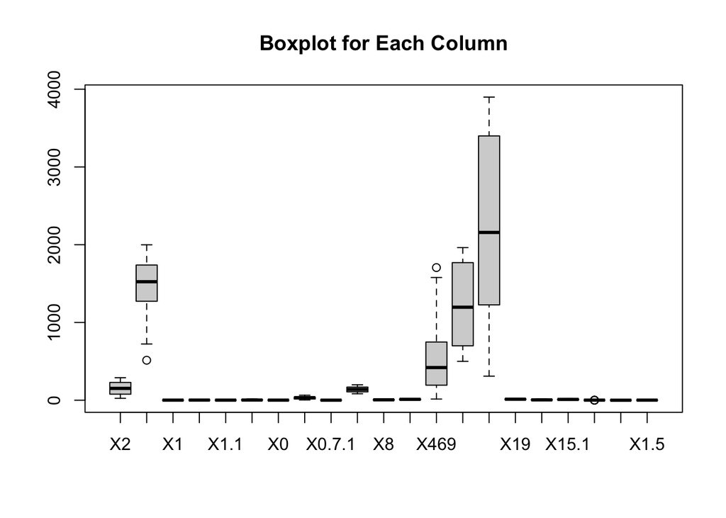

```r
# Create a boxplot for each column
boxplot(new_data, main="Boxplot for Each Column")
```